# Project 6 (Decision Tree-Titanic)

### MISY408 - Project 6

### Titanic Dataset

**Attributes**

- Survived: 0 = Not survived, 1 = Survived
- Pclass: Ticket class 1 = 1st class, 2 = 2nd class, 3 = 3rd class
- Name: Name of passenger
- Sex: male, female
- Age: Age of passenger
- Sibsp: # of siblings / spouses aboard the Titanic
- Parch: # of parents / children aboard the Titanic
- Ticket: Ticket number
- Fare: Passenger fare
- Cabin: Cabin number
- Embarked: Port of Embarkation C = Cherbourg, Q = Queenstown, S = Southampton

**Question1: Import the required libraries and read Titanic.csv file and save it in df dataframe, display the first five rows of df dataframe**

```python
import warnings
warnings.filterwarnings('ignore')

import pandas as pd
from sklearn import tree
import matplotlib.pyplot as plt

df = pd.read_csv('Titanic.csv')
df.head()
```

|  | PassengerId | Survived | Pclass | Name | Sex | Age | SibSp | Parch | Ticket | Fare | Cabin | Embarked |
| --- | --- | --- | --- | --- | --- | --- | --- | --- | --- | --- | --- | --- |
| 0 | 1 | 0 | 3 | Braund, Mr. Owen Harris | male | 22.0 | 1 | 0 | A/5 21171 | 7.2500 | NaN | S |
| 1 | 2 | 1 | 1 | Cumings, Mrs. John Bradley (Florence Briggs Th... | female | 38.0 | 1 | 0 | PC 17599 | 71.2833 | C85 | C |
| 2 | 3 | 1 | 3 | Heikkinen, Miss. Laina | female | 26.0 | 0 | 0 | STON/O2. 3101282 | 7.9250 | NaN | S |
| 3 | 4 | 1 | 1 | Futrelle, Mrs. Jacques Heath (Lily May Peel) | female | 35.0 | 1 | 0 | 113803 | 53.1000 | C123 | S |
| 4 | 5 | 0 | 3 | Allen, Mr. William Henry | male | 35.0 | 0 | 0 | 373450 | 8.0500 | NaN | S |

**Question 2: Exploratory data analysis. For this part you should:**

a. Check the shape of dataset

```python
df.shape
```

```
(891, 12)
```

b. Check if there is any missing values in the df dataframe

```python
df.isnull().sum()
```

```
PassengerId      0
Survived         0
Pclass           0
Name             0
Sex              0
Age            177
SibSp            0
Parch            0
Ticket           0
Fare             0
Cabin          687
Embarked         2
dtype: int64
```

c. drop the rows with missing values

```python
df1 = df.dropna()
df1.isnull().sum()
```

```
PassengerId    0
Survived       0
Pclass         0
Name           0
Sex            0
Age            0
SibSp          0
Parch          0
Ticket         0
Fare           0
Cabin          0
Embarked       0
dtype: int64
```

d. View the statistical summary of numerical variables in df dataframe (describe() method)

```python
df1.describe().transpose()
```

|  | count | mean | std | min | 25% | 50% | 75% | max |
| --- | --- | --- | --- | --- | --- | --- | --- | --- |
| PassengerId | 183.0 | 455.366120 | 247.052476 | 2.00 | 263.5 | 457.0 | 676.0 | 890.0000 |
| Survived | 183.0 | 0.672131 | 0.470725 | 0.00 | 0.0 | 1.0 | 1.0 | 1.0000 |
| Pclass | 183.0 | 1.191257 | 0.515187 | 1.00 | 1.0 | 1.0 | 1.0 | 3.0000 |
| Age | 183.0 | 35.674426 | 15.643866 | 0.92 | 24.0 | 36.0 | 47.5 | 80.0000 |
| SibSp | 183.0 | 0.464481 | 0.644159 | 0.00 | 0.0 | 0.0 | 1.0 | 3.0000 |
| Parch | 183.0 | 0.475410 | 0.754617 | 0.00 | 0.0 | 0.0 | 1.0 | 4.0000 |
| Fare | 183.0 | 78.682469 | 76.347843 | 0.00 | 29.7 | 57.0 | 90.0 | 512.3292 |

**Question 3:**

a. Create a frequency table to show the number of survived and number of not-survived passengers

```python
df1['Survived'].value_counts()
```

```
1    123
0     60
Name: Survived, dtype: int64
```

b. In the following, interpret the above frequency table's output.

123 passengers on the Titanic Survived and 60 passengers did not survive.

c. In the following, type a code to calculate average Fare and average Age for each Survived group (there should be only one table in the output)

```python
df1.groupby('Survived')[['Fare','Age']].mean()
```

| Survived | Fare | Age |
| --- | --- | --- |
| 0 | 64.048262 | 41.350000 |
| 1 | 85.821107 | 32.905854 |

d. In the following, interpret the above output. How average Fare and average Age are different for different Survived groups.

Of the people who did not survive the titanic, the average fare price was lower and the average age was higher than those who did survive

e. Create a crosstab to show the number of survived and the number of not-survived passengers for each Sex

```python
pd.crosstab(df1['Survived'], df1['Sex'])
```

| Sex Survived | female | male |
| --- | --- | --- |
| 0 | 6 | 54 |
| 1 | 82 | 41 |

f. In the following, interpret the above output.

6 female passengers on the titanic did not survive while 82 female passengers on the titanic did survive 54 male passengers on the titanic did not survive while 41 male passengers on the titanic did survive

**Question 4:**

a. Use Sex and Age as X variables and use 'Survived' as Y variable.

(**Note:** Since Sex is categorical variable, you should code it before using it. For example: create SexCode and set male to 0 and female to 1)

```python
df1.loc[df1['Sex'] == 'male', 'SexCode'] = 0
df1.loc[df1['Sex'] == 'female', 'SexCode'] = 1

Y = df1['Survived']
X = df1[['SexCode','Age']]
```

b. Create a Decision Tree with the X and Y variables

```
[Text(446.4, 362.4, 'Sex <= 0.5\ngini = 0.441\nsamples = 183\nvalue = [60, 123]'),
```

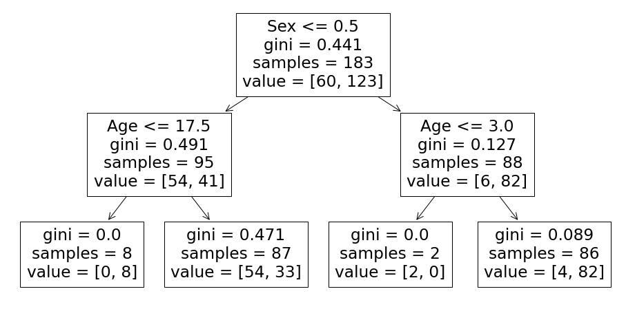

```python
clf = tree.DecisionTreeClassifier(max_depth = 2, random_state = 0)
clf = clf.fit(X, Y)

plt.figure(figsize = (16,8))
tree.plot_tree(clf, feature_names = ['Sex', 'Age'])
```

**Question 5:**

a. In the following, type a code to show the importance of each feature.

```python
clf.feature_importances_
```

```
array([0.71309244, 0.28690756])
```

b. In the following, Interpret the feature importance output

The output above indicates that the passengers Sex is 71.3% important, while the passengers Age is only 28.7% important in classifying whether or not someone has survived on the Titanic.

**Question 6:**

a. In the following, type a code to create a confusion matrix

```python
from sklearn.metrics import confusion_matrix

predictions = clf.predict(X)
cm = confusion_matrix(Y, predictions)
cm
```

```
array([[56,  4],
       [33, 90]], dtype=int64)
```

b. In the following, Interpret the confusion matrix. (please use the same template as the class notebooks)

Of the people who did not survive, we predicted 56 correctly. They are the "True Negatives". Of the people who survived, we predicted 90 correctly. They are the "True Positives". Of the people who did not survive, we predicted 4 to have survived (incorrectly). They are "False Positives". Of the people who survived, we predicted 33 to not have survived. They are "False Negatives".

**Question 7: In the following, type a code to show the accuracy of your model? (please use a print statement with placeholders to print the percentage of accuracy)**

```python
accuracy = clf.score(X,Y)
print('The decision tree is {:.2f}% accurate'.format(accuracy*100))
```

```
The decision tree is 79.78% accurate
```